# Taller de Interpolacion

#### Integrantes:

- Andres Camilo Giraldo
- Erika Alejandra Gonzalez
- Leonel Steven Londoño

#### Librerias requeridas

```r
require(PolynomF)
require(pracma)
```

### Punto 2

Al resolver el ejercicio se encuentra que la funcion que pasa por los 3 puntos es:

f(x)=10+ x + 4x^2 + (-23/4) x^2 * (x-1)

Para verificar que esta sea la funcion se evalua en los puntos dados:

f(0) = 10  
f(1) = 15  
f(2) = 5

Finalmente se halla la derivada de la funcion:

f’(x) = 1 + 4 * (2 * x) + ((-23/4) * (2 * x) * (x - 1) + (-23/4) * x^2)

Se evalua la derivada en x0 = 0 y se halla que la tangente es:

f’(0) = 1

```r
#Funcion que nos va a obtener la funcion que pasa por los puntos
interpolacionNewton = function(x, y, a) {
  cantidadPuntos = length(x)
  coeficientes = matrix(rep(NaN, times =cantidadPuntos^2), nrow = cantidadPuntos, ncol = cantidadPuntos)

  coeficientes[,1] = y
  coeficientes[1,2]=1
  for (i in 2:cantidadPuntos) {
    coeficientes[i:cantidadPuntos, i] = (coeficientes[i:cantidadPuntos, i-1] - coeficientes[(i-1):(cantidadPuntos-1), i-1] ) / (x[i:cantidadPuntos] - x[1:(cantidadPuntos-i+1)])
  }
  fAux1 = (coeficientes[1,2]-coeficientes[2,2])/(x[1]-x[2])
  fAux2 = (fAux1-coeficientes[3,3])/(x[1]-x[3])

  funcionInterpolada <- function(x) coeficientes[1,1]+coeficientes[1,2]*x+fAux1*x^2+fAux2*x^2*(x-1)

  return(funcionInterpolada)
}

#Valores de entrada
puntosX = c(0,1,2)
puntosY = c(10,15,5)
#Se obtiene el resultado
funcionInterpolada <- interpolacionNewton(puntosX,puntosY,1)
cat("\nFuncion que para por los tres puntos: f(x)=10+x+4*x^2+(-23/4)*x^2*(x-1) \n")
```

```
##
## Funcion que para por los tres puntos: f(x)=10+x+4*x^2+(-23/4)*x^2*(x-1)
```

```r
#Se comprueba que funcion sea correcta
cat("\nSe evalua la funcion en los puntos dados para comprobarla: \n")
```

```
##
## Se evalua la funcion en los puntos dados para comprobarla:
```

```r
cat("f(0) = ", funcionInterpolada(0), "\n")
```

```
## f(0) =  10
```

```r
cat("f(1) = ", funcionInterpolada(1), "\n")
```

```
## f(1) =  15
```

```r
cat("f(2) = ", funcionInterpolada(2), "\n")
```

```
## f(2) =  5
```

```r
#Para evaluar la tangete se deriva la funcion y se evalua
expresionFuncion <-expression(10+x+4*x^2+(-23/4)*x^2*(x-1))
derivada <-D(expresionFuncion,"x")
cat("\nDerivada de la funcion: ")
```

```
##
## Derivada de la funcion:
```

```r
print(derivada)
```

```
## 1 + 4 * (2 * x) + ((-23/4) * (2 * x) * (x - 1) + (-23/4) * x^2)
```

```r
cat("\nLa tangente evaluada en x0 es: f'(0) = ",
    1 + 4 * (2 * 0) + ((-23/4) * (2 * 0) * (0 - 1) + (-23/4) * 0^2))
```

```
##
## La tangente evaluada en x0 es: f'(0) =  1
```

### Punto 3:

Construya un polinomio del menor grado que interpole una funci´on f(x) en los siguientes datos: f(1) = 2; f(2) = 6; f’(1) = 3; f’(2) = 7; f’’(2) = 8

```r
f <-c(2,3,6,7,8)
x <-c(1,1,2,2,2)

policoef <-c()
policoef[1]=f[1]
policoef[2]=f[2]
policoef[3]=(-f[2])/(x[3]-x[1])
policoef[4]=((f[4]-(f[3]-f[2]))-(policoef[3]))/(x[4]-x[1])
policoef[5]= ((f[5]- (f[4]-(f[3]-f[2])))-(policoef[4]))/(x[5]-x[1])

print(policoef)
```

```
## [1]  2  3 -3  7 -3
```

```r
cat("polinomio")
```

```
## polinomio
```

```r
cat(policoef[1],"+",policoef[2],"( x-",x[1],")+",policoef[3],"( x-",x[2],")",x[3],"+",policoef[4],"( x-",x[2],")",x[3],"( x-",x[3],")",policoef[5],"( x-",x[2],")",x[4],"( x-",x[3],")",x[5])
```

```
## 2 + 3 ( x- 1 )+ -3 ( x- 1 ) 2 + 7 ( x- 1 ) 2 ( x- 2 ) -3 ( x- 1 ) 2 ( x- 2 ) 2
```

### Punto 4:

Con la función f(x) = lnx construya la interpolación de diferencias divididas en x0 = 1; x1 = 2 y estime el error en [1, 2]

```r
f <- function(x){
  return(log(x))
}

diferencias_divididas <- function(funcion_y){
  diferencias <- c(0)
  contador = 1

  diferencias[contador] = (funcion_y[contador+1]-funcion_y[contador])/(y[contador+1]-y[contador])
  contador=contador+1

  while( contador < 5){

    diferencias[contador] = (funcion_y[contador+1]-funcion_y[contador])/(y[contador+1]-y[contador])

    contador=contador+1

  }
  print(diferencias)
}

error <-function(f,deg,sec){
  x=0;
  while (x < deg){
    f= D(f,'x');
    x=x+1;
  }
  return (sec*abs(eval(f)));
}
funcion_y <- c(0)
y <- c(0)
contador <- 1


for (i in 1:5){

  imagen <- f(i)
  funcion_y[contador]=imagen
  y[contador]=i
  contador=contador+1
}

tabla = data.frame(y,funcion_y)
print(tabla)
```

```
##   y funcion_y
## 1 1 0.0000000
## 2 2 0.6931472
## 3 3 1.0986123
## 4 4 1.3862944
## 5 5 1.6094379
```

```r
#diferencias divididas
diferencias_divididas(funcion_y)
```

```
## [1] 0.6931472 0.4054651 0.2876821 0.2231436
```

```r
#error
lagrange1 <- abs((1.5-y[1])*(1.5-y[2])/factorial(2))

f = expression(log(x))
error_diferencias = error(f,2,lagrange1)


cat("Error: ",error_diferencias)
```

```
## Error:  0.03125
```

### Punto 7:

Sea f(x) = e^x en el intervalo de [0, 1] utilice el método de lagrange y determine el tamaño del paso que me produzca un error por debajo de 10−5. Es posible utilizar el polinomio de Taylor para interpolar en este caso? El polinomio de taylor da una aproximacion correcta hasta determinado punto de la funcion dada es de importancia tener en cuenta el centro del polinomio,dicho polinomio tiene grado 4.

```r
require(pracma)
f <- function( x )
{
  exp(x)
}
lagrange = function(x,y,n)
  {
  nLength = length(x)
  if(n < min(x) || max(x) < n) stop("Fin interpolacion")
  X = matrix(rep(x, times= nLength),  nLength,  nLength, byrow=T)
  meN = n - X; diag(meN) = 1
  miDd = X - t(X); diag(miDd) = 1
  Lnk = apply(meN, 1, prod)/apply(miDd, 2, prod)
  sum(y*Lnk)
}
graficas= function(pval,paso,paso1)
{
  curve(f, col= "green", from = -10, to= 10)
  curve(pval[1]*x^(4)+pval[2]*x^(3)+pval[3]*x^(2)+pval[4]*x+pval[5],add=TRUE, col="blue", from = -100, to= 100)
  curve(g, col= "red", from = -10, to= 10)
  curve(paso[1]*x^(4)+paso[2]*x^(3)+paso[3]*x^(2)+paso[4]*x+paso[5],add=TRUE, col="green", from = -100, to= 100 )
  curve(paso1[1]*x^(4)+paso1[2]*x^(3)+paso1[3]*x^(2)+paso1[4]*x+paso1[5],add=TRUE, col="green", from = -100, to= 100 )
  cat(pval[1],"x^(4)+",pval[2],"*x^(3)+",pval[3],"*x^(2)+",pval[4],"x+",pval[5],"/n")
  #positivo
  cat(paso[1],"x^(4)+",paso[2],"*x^(3)+",paso[3],"*x^(2)+",paso[4],"x+",paso[5],"/n")
  #negativo
  cat(paso1[1],"x^(4)+",paso1[2],"*x^(3)+",paso1[3],"*x^(2)+",paso1[4],"x+",paso1[5],"/n")

}


x<-c(0,0.25,0.5,0.75,1)
y<-f(x[1:5])
lagrange(x[1:5],y[1:5],0.5)
```

```
## [1] 1.648721
```

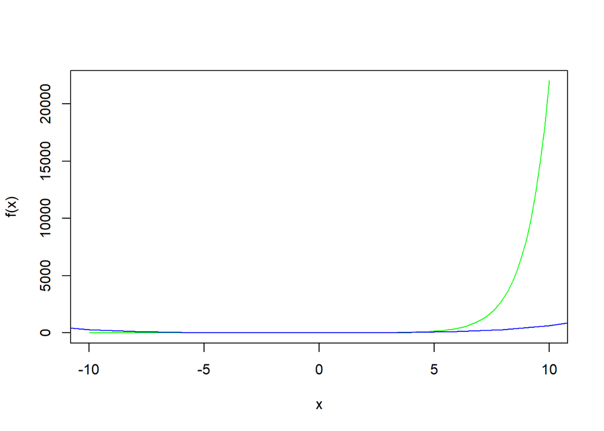

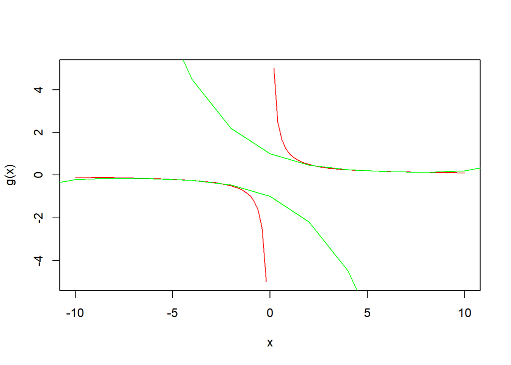

```
## 0.04166657 x^(4)+ 0.1666667 *x^(3)+ 0.5 *x^(2)+ 1 x+ 1 /n0.0003202768 x^(4)+ -0.008005558 *x^(3)+ 0.08004186 *x^(2)+ -0.4001401 x+ 1.000176 /n-0.0003203398 x^(4)+ -0.00800682 *x^(3)+ -0.08005132 *x^(2)+ -0.4001716 x+ -1.000215 /n
```

```r
f = function(x) exp(x)
g= function (x) 1/x
pval = taylor(f, 0, 4)
paso= taylor(g, 5, 4)
paso1=taylor(g,-5,4)

graficas(pval,paso,paso1)
```

### Punto 8:

Considere el comportamiento de gases no ideales se describe a menudo con la ecuaci´on virial de estado. los siguientes datos para el nitrógeno
$$N_2$$

```r
#Datos de Entrada
Temperatura <- c(100,200,300,400,500,600)
B <- c(-160, -35, -4.2, 9, 16.9, 21.3)

#Matriz de coeficientes
coeficientes <- matrix(c(rep(1:36)), byrow = T, nrow = 6, ncol = 6)

#Se llena la matriz de coeficientes
for (i in 1:6) {
  for (j in 1:6) {
    if(j == 1){
      coeficientes[i,j] <- 1
    }
    else{
      coeficientes[i,j] <- Temperatura[i]^(j-1)
    }
  }
}

#Se resuelve el sistema
solucionSistema <- solve(coeficientes,B)

Polinomio <- function(x){
  return (solucionSistema[1]
          +solucionSistema[2]*x
          +solucionSistema[3]*x^2
          +solucionSistema[4]*x^3
          +solucionSistema[5]*x^4
          +solucionSistema[6]*x^5)
}

cat("\n", "Polinomio interpolante para el caso: ",
          solucionSistema[1],
          "+",solucionSistema[2],"*x",
          "+",solucionSistema[3],"*x^2",
          "+",solucionSistema[4],"*x^3",
          "+",solucionSistema[5],"*x^4",
          "+",solucionSistema[6],"*x^5", "\n")
```

```
##
##  Polinomio interpolante para el caso:  -573.9 + 6.63535 *x + -0.03183458 *x^2 + 7.766667e-05 *x^3 + -9.404167e-08 *x^4 + 4.483333e-11 *x^5
```

```r
#Se evalua el polinomio en 450 K
segundoCoeficiente <- Polinomio (450)

cat("\nEl segundo coeficiente virial es: ", segundoCoeficiente)
```

```
##
## El segundo coeficiente virial es:  13.88437
```

```r
#Datos para hallar el tercer coeficiente
V = 227000
P = 1e-5
R = 8.314472

PV = P*V
RT = R*450

PVRT <- PV/RT
#Se obtiene PV/RT
cat("\nPV/RT con T = 450 es:",PVRT, "\n")
```

```
##
## PV/RT con T = 450 es: 0.0006067065
```

```r
#Se calcula el tercer coeficiente
tercerCoeficiente = ((PVRT)-1-(B/V))*(V^2)

cat("\nEl tercer coeficiente virial es: ", tercerCoeficiente[1], "\n")
```

```
##
## El tercer coeficiente virial es:  -51461417019
```

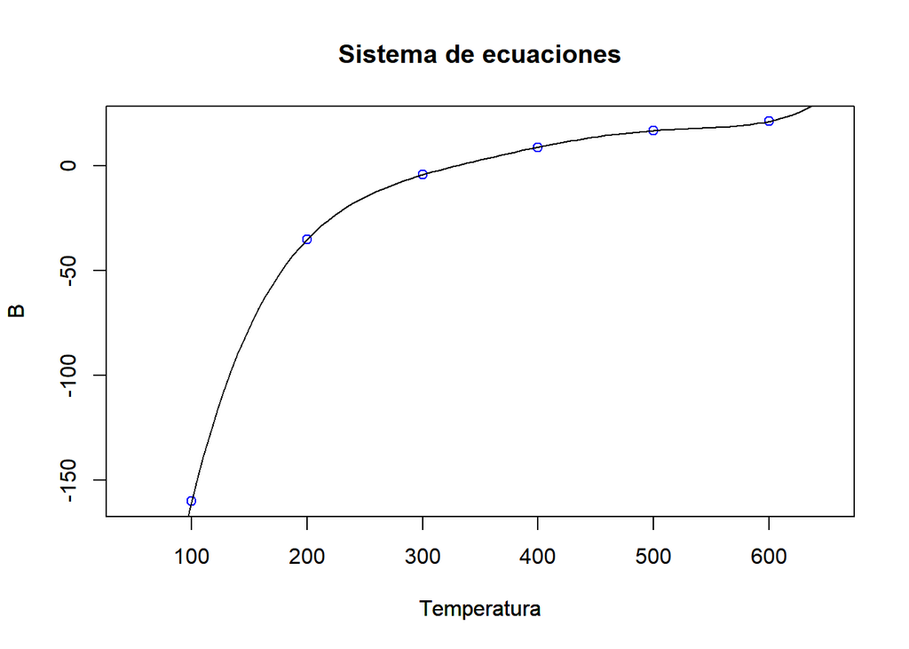

```r
#Se grafican los puntos y el polinomio
plot(Polinomio, xlim = c(50,650), col="white",main = "Sistema de ecuaciones", axes=FALSE, xlab="Temperatura", ylab = "B")
par(new=TRUE)
plot(Temperatura,B, xlim=c(50, 650), col="blue")
curve(Polinomio, add=T)
```

d)

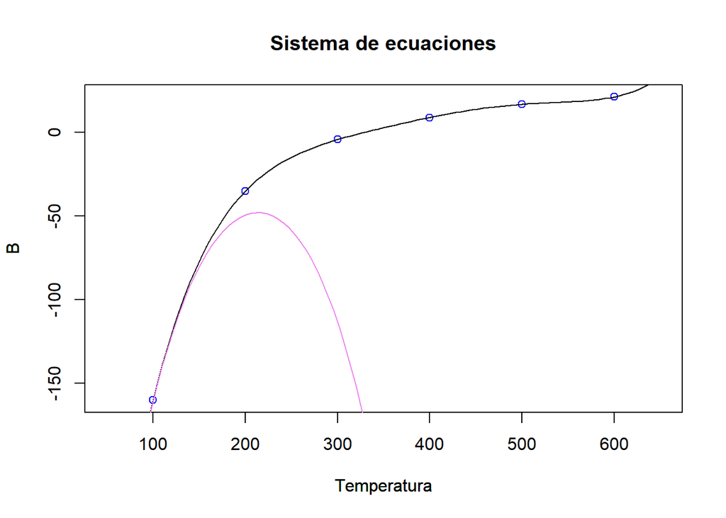

```r
plot(Polinomio, xlim = c(50,650), col="white",main = "Sistema de ecuaciones", axes=FALSE, xlab="Temperatura", ylab = "B")
par(new=TRUE)
plot(Temperatura,B, xlim=c(50, 650), col="blue")
curve(Polinomio, add=T)
#Se obtiene polinomio que resuelve el sistema usando la libreria PolynomF
PolinomioPorLibreria = poly_calc(Temperatura,B)

curve(PolinomioPorLibreria, col = "violet", add = T)
```

```r
cat("\nEl Polinomio usando la libreria PolynomF es: ")
```

```
##
## El Polinomio usando la libreria PolynomF es:
```

```r
print(PolinomioPorLibreria)
```

```
## -573.9 + 6.63535*x - 0.03183458*x^2 + 7.766667e-05*x^3 - 9.404167e-08*x^4
```

```r
#Comparando resultados
cat("\nB en T = 450 es:",PolinomioPorLibreria(450),"\n\n")
```

[output not shown]

```r
ValorPorLagrange = lagrangeInterp(Temperatura,B, 450)
cat("\nValor con la funcion LagrangeInterp en T=450 es:", ValorPorLagrange,"\n\n")
```

```
##
## Valor con la funcion LagrangeInterp en T=450 es: 13.88438
```

Se concluye que el metodo de lagrange es mas eficiente esto se debe por que: Usando lagrange el resultado se obtuvo con un total de 72 multiplicaciones mientras que el teorico re realizo con un total de 90, mucho mas grande al de lagrange.